# Chapter 2 - Linear Regression

*Describe the work you have done this week and summarize your learning.*

- Describe your work and results clearly.
- Assume the reader has an introductory course level understanding of writing and reading R code as well as statistical methods
- Assume the reader has no previous knowledge of your data or the more advanced methods you are using
1. Phase 1

```r
l2014 <- read.table("/home/juhana/Desktop/IODS-project/learning2014.txt", sep = ",", header = T)
str(l2014)
```

```
## 'data.frame':    166 obs. of  7 variables:
##  $ gender  : Factor w/ 2 levels "F","M": 1 2 1 2 2 1 2 1 2 1 ...
##  $ age     : int  53 55 49 53 49 38 50 37 37 42 ...
##  $ attitude: num  3.7 3.1 2.5 3.5 3.7 3.8 3.5 2.9 3.8 2.1 ...
##  $ deep    : num  3.58 2.92 3.5 3.5 3.67 ...
##  $ stra    : num  3.38 2.75 3.62 3.12 3.62 ...
##  $ surf    : num  2.58 3.17 2.25 2.25 2.83 ...
##  $ points  : int  25 12 24 10 22 21 21 31 24 26 ...
```

```r
head(l2014)
```

```
##   gender age attitude     deep  stra     surf points
## 1      F  53      3.7 3.583333 3.375 2.583333     25
## 2      M  55      3.1 2.916667 2.750 3.166667     12
## 3      F  49      2.5 3.500000 3.625 2.250000     24
## 4      M  53      3.5 3.500000 3.125 2.250000     10
## 5      M  49      3.7 3.666667 3.625 2.833333     22
## 6      F  38      3.8 4.750000 3.625 2.416667     21
```

This dataset is a modified dataset from its original data (http://www.helsinki.fi/~kvehkala/JYTmooc/JYTOPKYS3-data.txt). The dataset that I’m working with consists of 7 variables, which explain the answerers’ gender, age, attitude towards statistics, points of their exam (Course: Johdatus yhteiskuntatilastotieteeseen, syksy 2014) and their learning style.

2. Phase 2

```r
summary(l2014)
```

```
##  gender       age           attitude          deep            stra
##  F:110   Min.   :17.00   Min.   :1.400   Min.   :1.583   Min.   :1.250
##  M: 56   1st Qu.:21.00   1st Qu.:2.600   1st Qu.:3.333   1st Qu.:2.625
##          Median :22.00   Median :3.200   Median :3.667   Median :3.188
##          Mean   :25.51   Mean   :3.143   Mean   :3.680   Mean   :3.121
##          3rd Qu.:27.00   3rd Qu.:3.700   3rd Qu.:4.083   3rd Qu.:3.625
##          Max.   :55.00   Max.   :5.000   Max.   :4.917   Max.   :5.000
##       surf           points
##  Min.   :1.583   Min.   : 7.00
##  1st Qu.:2.417   1st Qu.:19.00
##  Median :2.833   Median :23.00
##  Mean   :2.787   Mean   :22.72
##  3rd Qu.:3.167   3rd Qu.:27.75
##  Max.   :4.333   Max.   :33.00
```

Here we have the summaries of the variables in this data. It is clear that the female gender is represented quite much better than the male gender (F/M = 110/56). The ages are distributed with a median of 22. Since the oldest answerer seems to be 55 years old, it is good to focus on median instead of mean.

```r
library(ggplot2)
library(GGally)
```

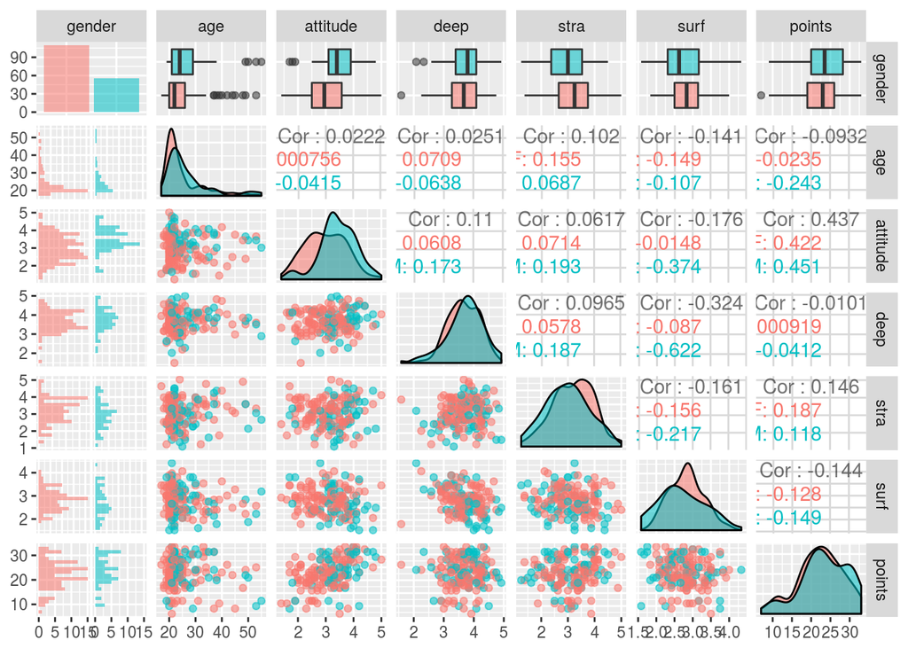

```r
ggpairs(l2014, mapping = aes(col = gender, alpha = 0.3), lower = list(combo = wrap("facethist", bins = 20)))
```

From this plotmatrix we can see the distributions and the correlation between the variables more cleary.

The biggest difference between the two genders is found from the attitude towards statistics, where men tend to score better. Another considerable difference can be found from the surface questions.

3. Phase 3

```r
summary(lm(points~age+attitude+stra, data=l2014))
```

```
##
## Call:
## lm(formula = points ~ age + attitude + stra, data = l2014)
##
## Residuals:
##      Min       1Q   Median       3Q      Max
## -18.1149  -3.2003   0.3303   3.4129  10.7599
##
## Coefficients:
##             Estimate Std. Error t value Pr(>|t|)
## (Intercept) 10.89543    2.64834   4.114 6.17e-05 ***
## age         -0.08822    0.05302  -1.664   0.0981 .
## attitude     3.48077    0.56220   6.191 4.72e-09 ***
## stra         1.00371    0.53434   1.878   0.0621 .
## ---
## Signif. codes:  0 '***' 0.001 '**' 0.01 '*' 0.05 '.' 0.1 ' ' 1
##
## Residual standard error: 5.26 on 162 degrees of freedom
## Multiple R-squared:  0.2182, Adjusted R-squared:  0.2037
## F-statistic: 15.07 on 3 and 162 DF,  p-value: 1.07e-08
```

Here we see a summary of a fitted regression model with three explanatory variables (age$=x_1$, attitud$=x_2$e and strategic learning $=x_3$) and the target value (points$=y$). This statistical test is testing how well the target value ($y$) corresponds to the explanatory variables ($x_1, x_2, x_3$), if we assume that there is a linear regression between the variables, so that $y = \alpha + \beta_1x_1 + \beta_2x_2 + \beta_3x_3 + \epsilon$, where $\epsilon$ is assumed to be a normally distributed error variable with a mean of 0.

In this particular model we see that $\alpha = 10.90, \beta_1 = -0.090, \beta_2=3.50, \beta_3 = 1.00$. Since $\beta_2=3.50$ is statistically the only significant result, we might remove the variables $x_1$ and $x_3$, and fit the model again with only one explanatory variable. So we get:

```r
summary(lm(points~attitude,data=l2014))
```

```
##
## Call:
## lm(formula = points ~ attitude, data = l2014)
##
## Residuals:
##      Min       1Q   Median       3Q      Max
## -16.9763  -3.2119   0.4339   4.1534  10.6645
##
## Coefficients:
##             Estimate Std. Error t value Pr(>|t|)
## (Intercept)  11.6372     1.8303   6.358 1.95e-09 ***
## attitude      3.5255     0.5674   6.214 4.12e-09 ***
## ---
## Signif. codes:  0 '***' 0.001 '**' 0.01 '*' 0.05 '.' 0.1 ' ' 1
##
## Residual standard error: 5.32 on 164 degrees of freedom
## Multiple R-squared:  0.1906, Adjusted R-squared:  0.1856
## F-statistic: 38.61 on 1 and 164 DF,  p-value: 4.119e-09
```

4. Phase 4

Another important value in this summary is 4.12e-09. It means that if we have set a null hyphotesis $H_0:\beta=0$, meaning that there is no correlation between points an attitude, the probability to get results like this. When we get a value of this size, it gives as a reason to reject the null hyphotesis and claim that there is a statistically significant correlation between attitude and points.

A value called multiple R-squared can also be found from the summary. This value basicly tells how well the model fits with our data and it is always a value between 0 and 1. The closer the value is to 1, the better our model fits the data. In this case the value is 0.1906, which indicates that our model does not fit the data very well.

As we can see from the following plot, occasionally the observation are quite far away from our regression model.

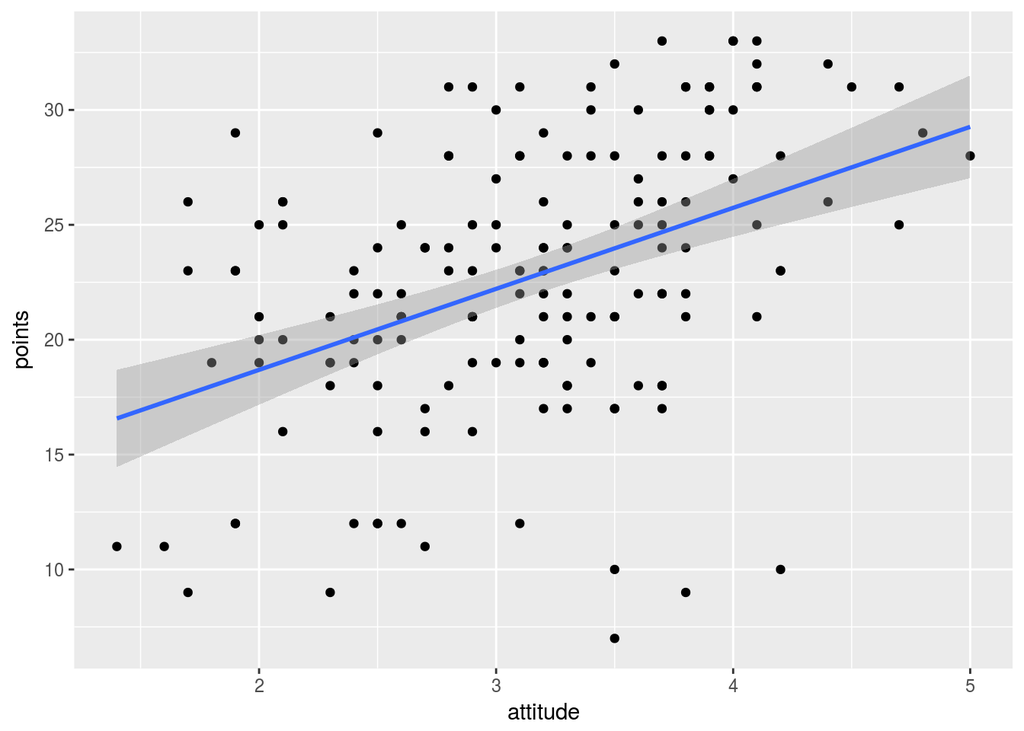

```r
qplot(attitude, points, data = l2014) + geom_smooth(method = "lm")
```

5. Phase 5

In the following series of plots we can see some analysis of the residuals. The first picture shows the residuals against our fitted model. It seems that our residuals are spread out in quite an even way.

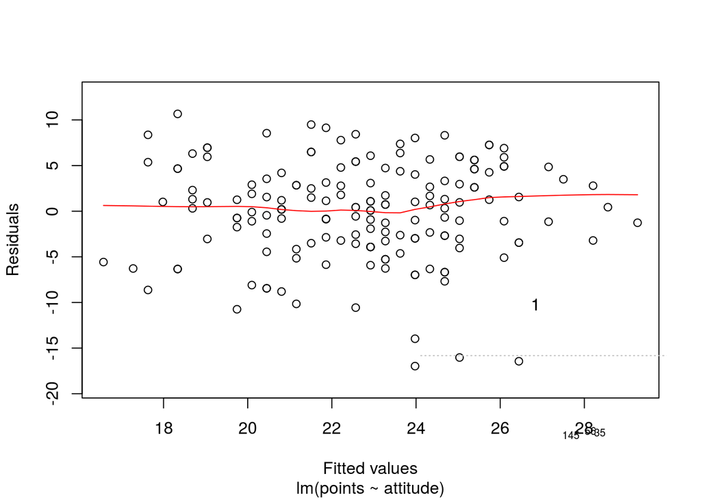

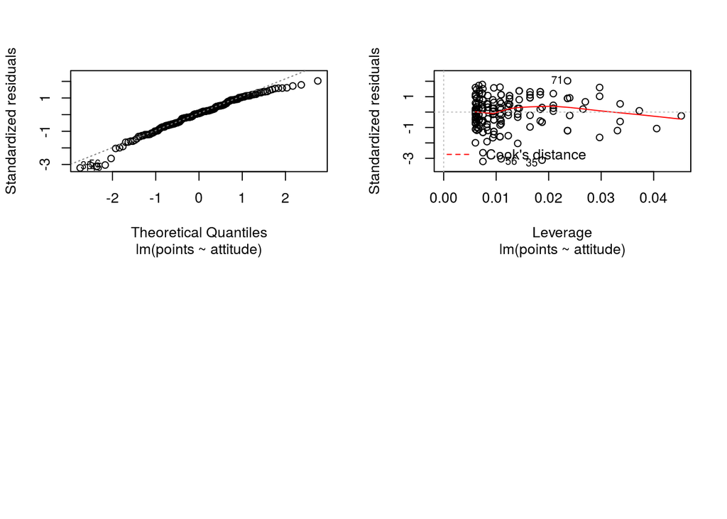

```r
plot(lm(points~attitude, data=l2014), which = c(1,2,5), par(mfrow=c(2,2)) )
```